# Wykład 4 – notatki

Maciej Beręsewicz

Na dzisiejszych zajęciach zajmiemy się analizą spółek giełdowych, wśród których znajdowały się spółki będące w stanie upadłości. Zadaniem naszym jest zweryfikowanie, które zmienne mogą być użyte do przewidywania oraz czy są jakieś graniczne wartości wykorzystanych zmiennych, po których można takie spółki rozróżnić.

Aby wstawić miejsce, w którym możemy pisać kody należy użyć skrótu CTRL + ALT + I.

```r
library(readxl)
#install.packages("tidyverse") ## kolekcja pakietów do analizy danych
library(tidyverse)
```

Zacznijmy od wczytania danych o spółkach

```r
spolki <- read_excel(path = "../data-raw/spolki_akcyjne_bankrut.xlsx",
                     col_names = c("id", "roa", "zysk_bilans", "wsk_bie_ply", "zob_akt", "rotacja", "grupa"),
                     skip = 1)
spolki
```

| id | roa | zysk_bilans | wsk_bie_ply | zob_akt | rotacja | grupa |
| --- | --- | --- | --- | --- | --- | --- |
| 1 | 0.020996705 | 0.059044778 | 0.94099005 | 0.66454103 | 132.05009 | bankrut |
| 2 | -0.247052839 | -0.075973724 | 0.50797657 | 0.93286443 | 506.52993 | bankrut |
| 3 | -0.015879051 | 0.023608184 | 1.20560393 | 0.60091395 | 367.24476 | bankrut |
| 4 | 0.173661360 | 0.150506512 | 1.70599667 | 0.48029869 | 170.28695 | bankrut |
| 5 | 0.050163456 | 0.067552341 | 1.03861730 | 0.73879753 | 218.86543 | bankrut |
| 6 | 0.019185964 | 0.086903157 | 1.12678182 | 0.64340864 | 363.40989 | bankrut |
| 7 | -0.135710610 | -0.111874127 | 1.27910781 | 0.45747677 | 267.66982 | bankrut |
| 8 | -0.067756358 | -0.010884136 | 0.86051528 | 0.80095586 | 124.36046 | bankrut |
| 9 | -0.206056000 | -0.173125333 | 0.94318858 | 0.81701094 | 338.21349 | bankrut |
| 10 | 0.011759000 | 0.069884845 | 1.16286461 | 0.73343693 | 120.90206 | bankrut |

[output cut: 170 more lines]

Robimy proste podsumowanie aby sprawdzić jak dużo mamy spółek zdrowych i chorych. Zrobimy to na dwa sposoby:

1. z wykorzystaniem funkcji table z “czystego R”

```r
table(spolki$grupa)
```

```
bankrut  zdrowa
     90      90
```

2. z wykorzystaniem pakietu dplyr i funkcji count

```r
count(spolki, grupa, name = "liczba")
```

| grupa | liczba |
| --- | --- |
| bankrut | 90 |
| zdrowa | 90 |

Mamy następujące hipotezy, które będziemy weryfikowali

1. wsk_bie_ply jeżeli jest < 1.2 -> możliwy wskaźnik bankructwa
2. zob_akt im wyższa wartość tym “większe problemy”
3. roa i zysk_bilans < 0 -> może nas niepokoić

Jeżeli chcemy sprawdzić czy dwie lub więcej grup różnią się ze względu na jakieś zmienne, najlepiej użyć wykres pudełkowy (boxplot)

```r
par(mfrow = c(2, 2))
boxplot(roa ~ grupa, data = spolki, main = "ROA")
boxplot(zysk_bilans ~ grupa, data = spolki, main = "Zysk do bilansu")
```

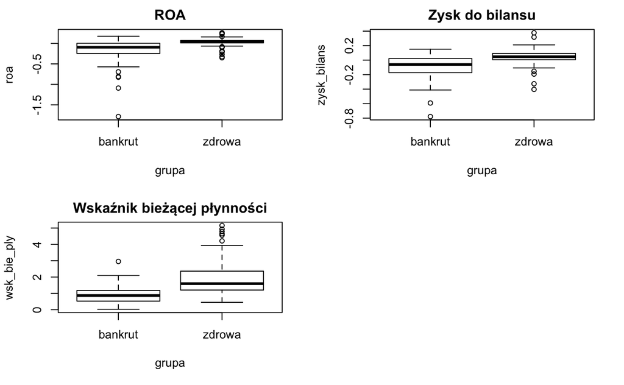

```r
boxplot(wsk_bie_ply ~ grupa, data = spolki, main = "Wskaźnik bieżącej płynności")
boxplot(zob_akt ~ grupa, data = spolki, main = "Zobowiązania krótkoterminowe")
```

[output not shown]

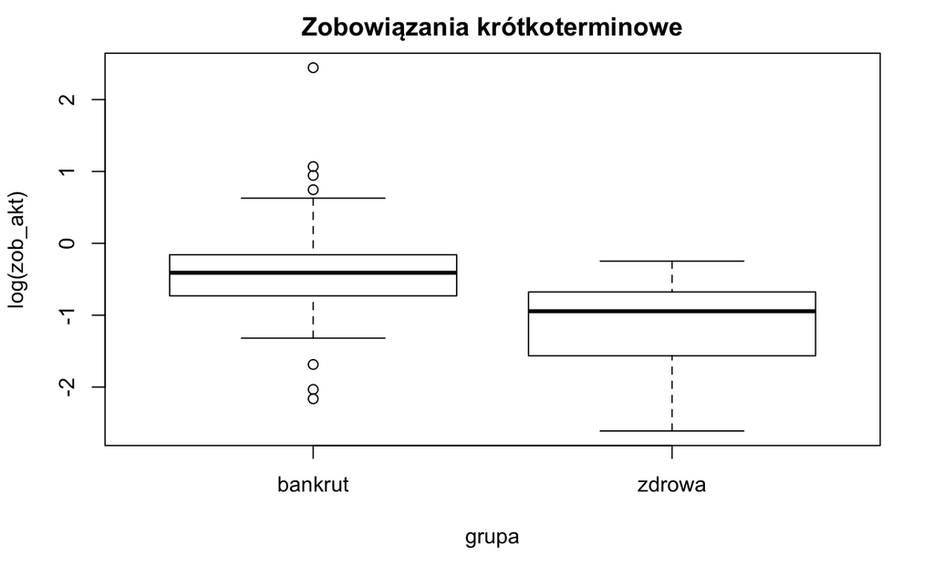

```r
boxplot(log(zob_akt) ~ grupa, data = spolki, main = "Zobowiązania krótkoterminowe")
```

Sprawdźmy jak wyglądają zależności między danymi wykorzystując wykres rozrzutu

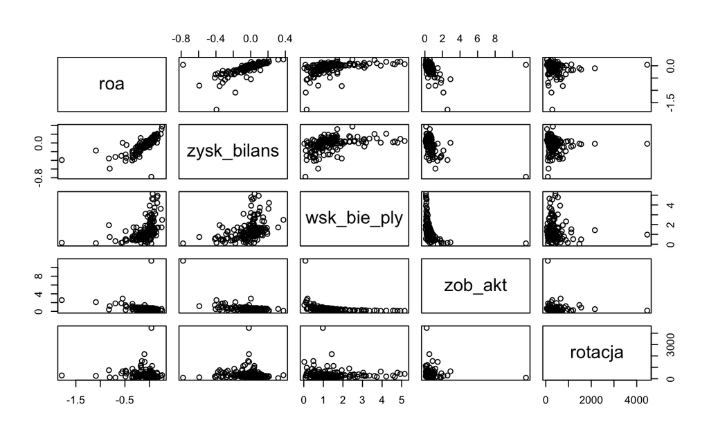

```r
pairs(spolki[, 2:6])
```

```r
round(cor(spolki[, 2:6], method = "spearman"), 2)
```

```
              roa zysk_bilans wsk_bie_ply zob_akt rotacja
roa          1.00        0.85        0.58   -0.44   -0.28
zysk_bilans  0.85        1.00        0.48   -0.38   -0.28
wsk_bie_ply  0.58        0.48        1.00   -0.71   -0.06
zob_akt     -0.44       -0.38       -0.71    1.00   -0.20
rotacja     -0.28       -0.28       -0.06   -0.20    1.00
```

1. wsk_bie_ply jeżeli jest < 1.2 -> możliwy wskaźnik bankructwa

count(zbiór danych, zmienna grupująca/zmienne grupujące)

```r
count(spolki, grupa, wsk = wsk_bie_ply <= 1.2)
```

| grupa | wsk | n |
| --- | --- | --- |
| bankrut | FALSE | 19 |
| bankrut | TRUE | 71 |
| zdrowa | FALSE | 68 |
| zdrowa | TRUE | 22 |

2. zob_akt im wyższa wartość tym “większe problemy”

```r
aggregate(zob_akt ~ grupa, data = spolki, FUN = median)
```

| grupa | zob_akt |
| --- | --- |
| bankrut | 0.6637620 |
| zdrowa | 0.3886661 |

```r
aggregate(zob_akt ~ grupa, data = spolki, FUN = mean)
```

| grupa | zob_akt |
| --- | --- |
| bankrut | 0.8695227 |
| zdrowa | 0.3808283 |

3. roa i zysk_bilans < 0 -> może nas niepokoić

```r
count(spolki, grupa, roa < 0)
```

| grupa | roa < 0 | n |
| --- | --- | --- |
| bankrut | FALSE | 25 |
| bankrut | TRUE | 65 |
| zdrowa | FALSE | 77 |
| zdrowa | TRUE | 13 |

```r
count(spolki, grupa, zysk_bilans < 0)
```

| grupa | zysk_bilans < 0 | n |
| --- | --- | --- |
| bankrut | FALSE | 34 |
| bankrut | TRUE | 56 |
| zdrowa | FALSE | 71 |
| zdrowa | TRUE | 19 |

Średnia wartość roa wynosiła -0.07 co oznacza, że … (wpisane ręcznie)

Średnia wartość roa wynosiła -0.0715 co oznacza, że … (wyliczone)

# Potokowe przetwarzanie danych

h( f( g(x) ) )

x > g() > f() > h()

zaparkuj( jedź_prosto( skręc_w_lewo(samochód) ) )

samochód > skręć_w_lewo > jedź_prosto > zaparkuj

```r
round(mean(spolki$roa),3) ## wersja zagnieżdżona
```

```
[1] -0.071
```

```r
spolki$roa %>% mean(.) %>% round(.,3) ## wersja z przetwarzaniem potokowym
```

```
[1] -0.071
```

Wykorzystamy pakiet dplyr do policzenia podsumowania

```r
summarise( group_by(spolki, grupa),  m = median(roa))
```

| grupa | m |
| --- | --- |
| bankrut | -0.09328940 |
| zdrowa | 0.04140816 |

```r
spolki %>%
  group_by(grupa) %>%
  summarise(m = median(roa))
```

| grupa | m |
| --- | --- |
| bankrut | -0.09328940 |
| zdrowa | 0.04140816 |

[output not shown]

Robimy wprowadzenie pakietu ggplot2

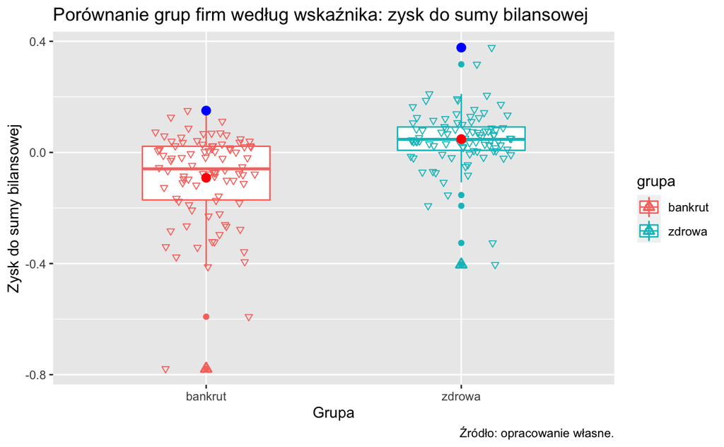

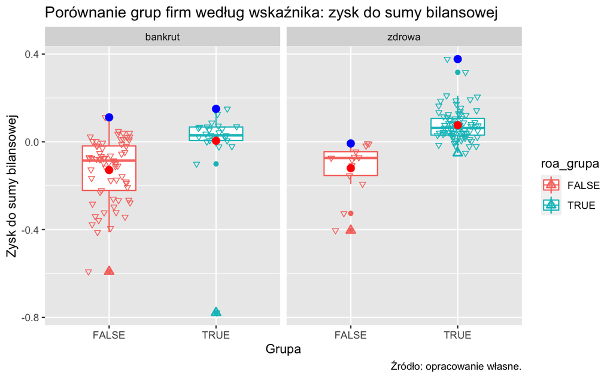

Histogram

– rotacja - rotacja aktywów (w dniach)=średnia wartość majątku/przychody ze sprzedaży netto * liczba dni

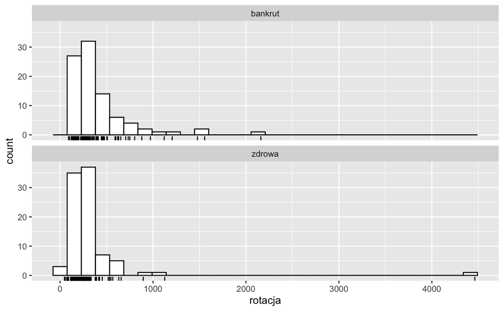

Wykres rozrzutu

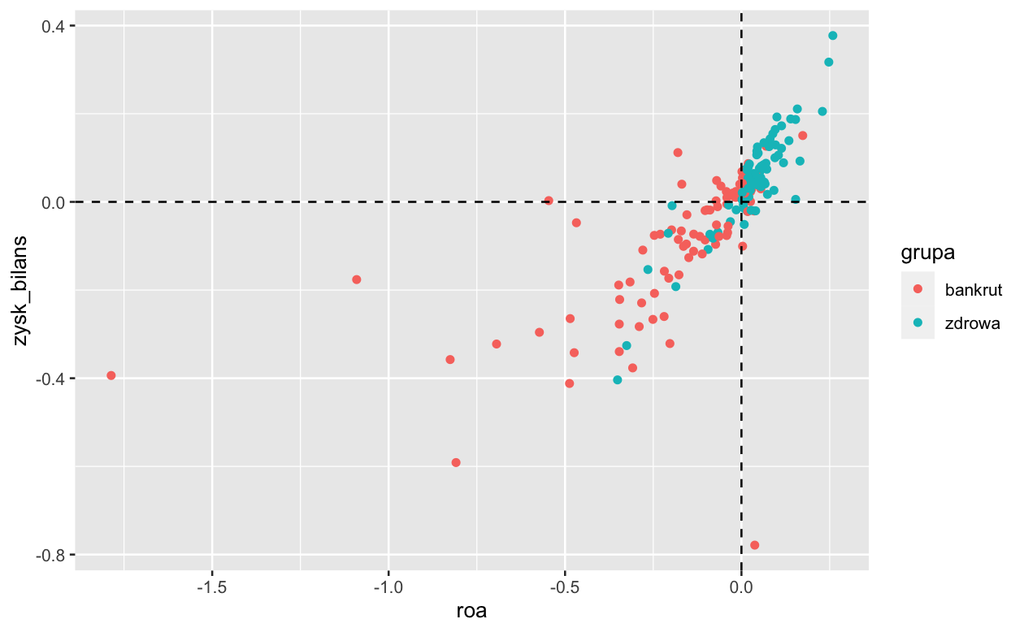

W jaki sposób możemy zapisywać wykresy

```r
getwd()
```

```
[1] "/Users/berenz/git/dydaktyka/nad2/nad2-2021/notebooks"
```

Zapis do obiektu typu RDS możliwy jest tylko i wyłącznie dla jednego obiektu

```r
getwd()
```

```
[1] "/Users/berenz/git/dydaktyka/nad2/nad2-2021/notebooks"
```